# R Tutorial: Statistical Inference 1

Statistical hypotheses, (un)paired t-tests, (M)ANOVA and the Bootstrap

Philipp Leppert

22.01.2021

Reading time: 25 minutes (4,872 words)

## 1. Introduction

### 1.1 R packages & Data

The following packages are required for this tutorial.

```r
library(ggplot2)
library(dplyr)
library(tidyr)
library(forcats)
library(stringr)
library(broom)
library(car)
library(boot)
library(heplots)
library(mvnormalTest)
```

The practical examples in the following sections are always illustrated with simulated data, so there is no need to load a dataset.

### 1.2 Hypothesis testing

With a statistical hypothesis we want to test if there is evidence against a statement about the nature of a population (consider for example a parameter like the mean or median). Before testing a statistical hypothesis the probability of error or the **significance level (α)** has to be set. The corresponding **confidence interval** is **1-α**. So for example a significance level of 5 % (or 0.05) reflects a 95 % confidence interval (0.95).

Rejecting the null hypothesis after a statistical test is denoted as either:

- a significant change (two-sided test),
- a significant decrease (left-sided test) or
- a significant increase (right-sided test)

By design the result of a statistical test is never unequivocal evidence for the change/decrease/increase of a measure, even when the null hypothesis is rejected at a very low significane level. Also, *a significant change can be negligibly small*. Always remember that it is required to *set the significane level before calculating the p value*, in order to not adjust **α** in hindsight to obtain the desired result.

The signficance level in the following examples is always set to 5 %.

## 2. Student’s t-test

The Student’s t-test is a statistical hypothesis test, in which the test statistic follows the [Student’s t-distribution](https://en.wikipedia.org/wiki/Student%27s_t-distribution). Commonly, it is used to determine if the means of two groups of data are significantly different from each other. Still, it can also be applied to a single sample, where the mean is tested against a specific value. Below is a representation with different degrees of freedom.

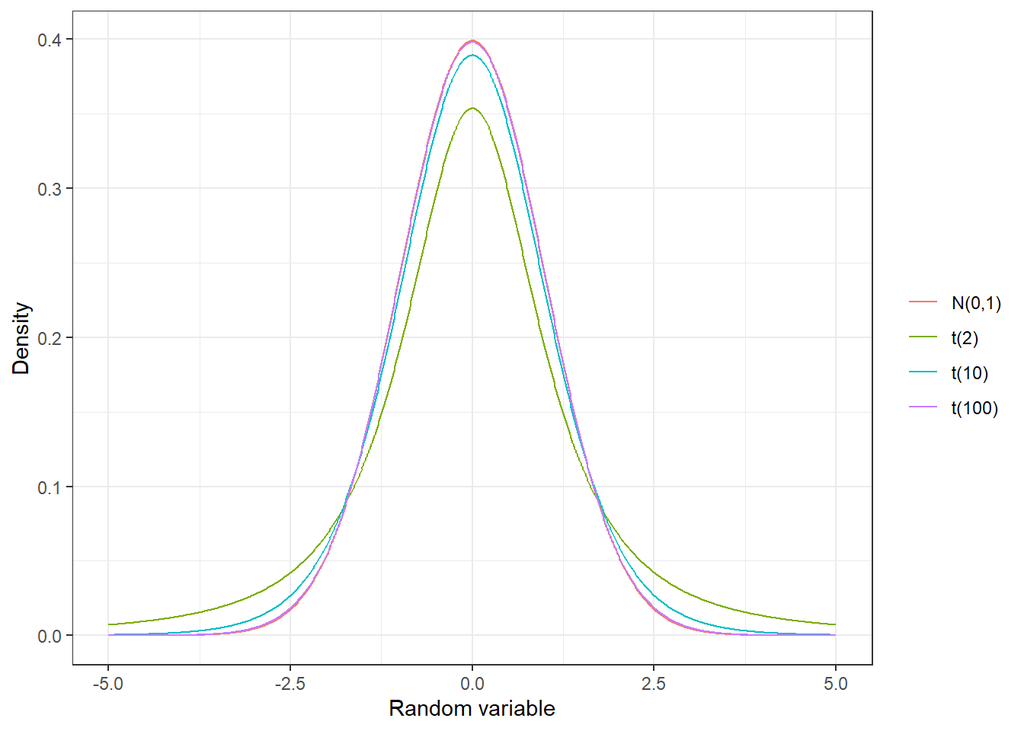

For higher degrees of freedom the t-distribution approximates the normal distribution. However, note the difference in the tails between both distributions.

### 2.1 One-sample t-test

In its most simple form the t-test is a location test of whether the mean of a population has a value specified in the null hypothesis. The data, and hence the sample mean, must follow a normal distribution in order for the test to work.

#### Data

```r
set.seed(123)
dataset_1 <- tibble(
  id = as.character(c(1:75)),
  variable = rnorm(n = 75, mean = 5, sd = 3)
  )

dataset_1
```

```
## # A tibble: 75 x 2
##    id    variable
##    <chr>    <dbl>
##  1 1         3.32
##  2 2         4.31
##  3 3         9.68
##  4 4         5.21
##  5 5         5.39
##  6 6        10.1
##  7 7         6.38
##  8 8         1.20
##  9 9         2.94
## 10 10        3.66
## # ... with 65 more rows
```

#### Histogram

With a histogram, the distribution of the `variable` can be visualized.

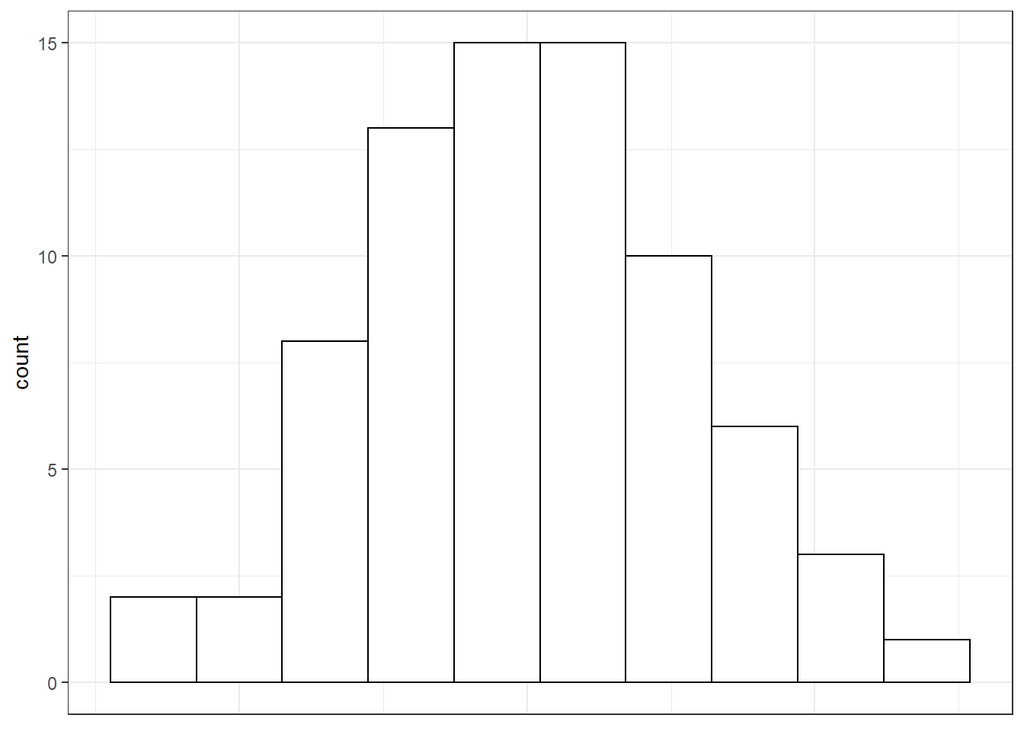

```r
ggplot(data = dataset_1,
       aes(x = variable)) +
  geom_histogram(fill = "white", color = "black", bins = 10) +
  theme(axis.title.x=element_blank(),
        axis.text.x=element_blank(),
        axis.ticks.x=element_blank())
```

This looks normally distributed.

#### Normality

Before I compute the t-test, the normality assumption is checked. As the sample is quite small, the central limit theorem will not apply. However, a **Shapiro-Wilk Normality Test** can be used to test whether the data follows a normal distribution. The null hypothesis is hence that the data is normally distributed. This test can be computed with function `shapiro.test()`.

```r
shapiro.test(dataset_1$variable)
```

```
##
##  Shapiro-Wilk normality test
##
## data:  dataset_1$variable
## W = 0.99421, p-value = 0.9834
```

The test shows a p-value of 0.98. Hence, there is no evidence to reject the null hypothesis in favor of the alternative that the data is not normally distributed.

#### t-test (two-tailed)

Finally we can run the t-test which is implemented in function `t.test()`. The theoretical mean against which the hypothesis test is carried out (`mu`) is 0 by default. With argument `alternative =` a two- or one-tailed test can be applied. Below, the null hypothesis that the population mean of `variable` is equal to zero (`mu = 0`), is rejected in favor of the alternative that it is not equal to zero.

```r
t.test(dataset_1$variable,
       alternative = "two.sided",
       mu = 0, conf.level = 0.95)
```

```
##
##  One Sample t-test
##
## data:  dataset_1$variable
## t = 15.679, df = 74, p-value < 2.2e-16
## alternative hypothesis: true mean is not equal to 0
## 95 percent confidence interval:
##  4.433596 5.724500
## sample estimates:
## mean of x
##  5.079048
```

To check this result, I am computing the test statistic and confidence interval by hand.

```r
knitr::kable(tibble(
  stderr = sqrt( var(dataset_1$variable) / length(dataset_1$variable) ),
  tstat = (mean(dataset_1$variable) - 0) / stderr,
  pval = 2 * pt(q = -abs(tstat), df = length(dataset_1$variable) -1),
  alpha = 1-0.95,
  error = qt(p = 1 - alpha / 2, df = length(dataset_1$variable) -1) * stderr,
  lower_ci = mean(dataset_1$variable) - error,
  upper_ci = mean(dataset_1$variable) + error)
  )
```

| stderr | tstat | pval | alpha | error | lower_ci | upper_ci |
| --- | --- | --- | --- | --- | --- | --- |
| 0.3239338 | 15.67928 | 0 | 0.05 | 0.6454521 | 4.433596 | 5.7245 |

#### t-test (one-tailed)

A one-tailed t-test is used for the null hypothesis that the population mean of `variable` is **greater than** or equal to 6. The null hypothesis rejected in favor of the alternative that it is less than 6.

```r
t.test(dataset_1$variable,
       alternative = "less",
       mu = 6, conf.level = 0.95)
```

```
##
##  One Sample t-test
##
## data:  dataset_1$variable
## t = -2.843, df = 74, p-value = 0.002886
## alternative hypothesis: true mean is less than 6
## 95 percent confidence interval:
##      -Inf 5.618627
## sample estimates:
## mean of x
##  5.079048
```

Next, I test the null hypothesis that the the population mean of `variable` is **less than** or equal to 4. The null hypothesis is rejected in favor of the alternative that it is greater than 4.

```r
t.test(dataset_1$variable,
       alternative = "greater",
       mu = 4, conf.level = 0.95)
```

```
##
##  One Sample t-test
##
## data:  dataset_1$variable
## t = 3.3311, df = 74, p-value = 0.000676
## alternative hypothesis: true mean is greater than 4
## 95 percent confidence interval:
##  4.539469      Inf
## sample estimates:
## mean of x
##  5.079048
```

Again, I show the caluclation for both one-tailed tests.

```r
knitr::kable(tibble(
  stderr = sqrt( var(dataset_1$variable) / length(dataset_1$variable) ),
  tstat = (mean(dataset_1$variable) - 6) / stderr,
  pval = pt(q = -abs(tstat), df = length(dataset_1$variable) -1),
  error = qt(p = 0.95, df = length(dataset_1$variable) -1) * stderr,
  lower_ci = -Inf,
  upper_ci = mean(dataset_1$variable) + error)
)
```

| stderr | tstat | pval | error | lower_ci | upper_ci |
| --- | --- | --- | --- | --- | --- |
| 0.3239338 | -2.843025 | 0.0028864 | 0.5395787 | -Inf | 5.618627 |

```r
knitr::kable(tibble(
  stderr = sqrt( var(dataset_1$variable) / length(dataset_1$variable) ),
  tstat = (mean(dataset_1$variable) - 4) / stderr,
  pval = pt(q = abs(tstat), df = length(dataset_1$variable) -1, lower.tail = FALSE),
  error = qt(p = 0.95, df = length(dataset_1$variable) -1) * stderr,
  lower_ci = mean(dataset_1$variable) - error,
  upper_ci = Inf)
)
```

| stderr | tstat | pval | error | lower_ci | upper_ci |
| --- | --- | --- | --- | --- | --- |
| 0.3239338 | 3.331076 | 0.000676 | 0.5395787 | 4.539469 | Inf |

### 2.2 Two-samples unpaired t-test

The independent or unpaired samples t-test is used to compare the mean of two **unrelated** groups. Each group is a sample of one of the two populations being compared. Again, we have to check that the data of the two groups is normally distributed. Additionally, the variance of the two groups now plays a role and is assumed to be equal (**variance homogeneity**).

#### 2.2.1 Equal variance

##### Data

For the dataset in this section I create 50 observations for *men* and *women* each of a `variable` of interest. Both groups are normally distributed with an identical standard deviation but their mean is different as seen below.

```r
set.seed(123)
dataset_2 <- tibble(
  men = rnorm(50, mean = 5, sd = 2),
  women = rnorm(50, mean = 8, sd = 2)
  ) %>%
  pivot_longer(cols = c(men, women),names_to = "group", values_to = "variable")

dataset_2
```

```
## # A tibble: 100 x 2
##    group variable
##    <chr>    <dbl>
##  1 men       3.88
##  2 women     8.51
##  3 men       4.54
##  4 women     7.94
##  5 men       8.12
##  6 women     7.91
##  7 men       5.14
##  8 women    10.7
##  9 men       5.26
## 10 women     7.55
## # ... with 90 more rows
```

##### Boxplot

The distribution of `variable` within each group is shown below with two boxplots.

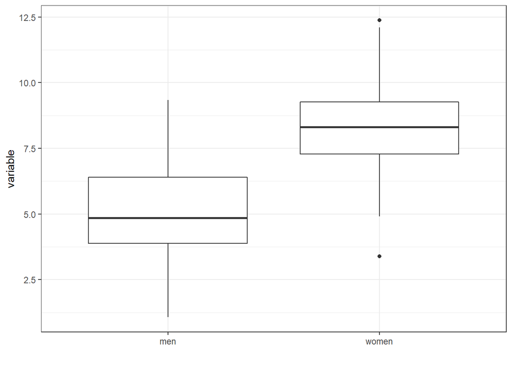

```r
ggplot(data = dataset_2,
       aes(x = group, y = variable)) +
  geom_boxplot() +
  labs(x = "")
```

##### Normality

The Shapiro-Wilk-Test is again used to check the assumption of normally distributed data. It is carried out for each group individually.

```r
dataset_2 %>%
  filter(group == "men")  %>%
  pull(variable) %>%
  shapiro.test()
```

```
##
##  Shapiro-Wilk normality test
##
## data:  .
## W = 0.98928, p-value = 0.9279
```

```r
dataset_2 %>%
  filter(group == "women")  %>%
  pull(variable) %>%
  shapiro.test()
```

```
##
##  Shapiro-Wilk normality test
##
## data:  .
## W = 0.99073, p-value = 0.9618
```

For both grouphs, the null hypothesis that the data is normally distributed cannot be rejected.

##### Variance homogeneity

The function `var.test()` performs an **F-test** to compare the variances of the two groups regarding `variable`. The null hypothesis is that the ratio of the variances is *equal* to 1.

```r
var.test(variable ~ group, data = dataset_2,
         ratio = 1, alternative = "two.sided",
         conf.level = 0.95)
```

```
##
##  F test to compare two variances
##
## data:  variable by group
## F = 1.0456, num df = 49, denom df = 49, p-value = 0.8766
## alternative hypothesis: true ratio of variances is not equal to 1
## 95 percent confidence interval:
##  0.5933642 1.8425790
## sample estimates:
## ratio of variances
##            1.04562
```

There is no evidence to reject the null hypothesis. So it is fine to assume homoskedasticity.

##### t-test (two-tailed)

The t-test for unpaired groups can be computed in the same way as in the one-sample case. The argument `paired =` is set to `FALSE` by default in function `t.test()`. Since there was no evidence against homoskedasticity, the argument `var.equal=TRUE` is added. The null hypothesis is that the difference of the mean value of `variable` between `men` and `women` is equal to zero.

```r
t.test(variable ~ group, data = dataset_2,
       alternative = "two.sided",
       mu = 0, paired = FALSE,
       var.equal = TRUE)
```

```
##
##  Two Sample t-test
##
## data:  variable by group
## t = -8.8019, df = 98, p-value = 4.799e-14
## alternative hypothesis: true difference in means is not equal to 0
## 95 percent confidence interval:
##  -3.950893 -2.497126
## sample estimates:
##   mean in group men mean in group women
##            5.068807            8.292817
```

The null hypothesis is rejected in favor of the alternative that there is a significant difference in the groups’ means.

Below, I computed the output of `t.test()`. The confidence interval now refers to the difference between the mean of the two groups.

```r
knitr::kable(
  tibble(
    stderr = sqrt(var(dataset_2[dataset_2$group == "men", ]$variable) / 50 +
                    var(dataset_2[dataset_2$group == "women", ]$variable) / 50),
    tstat = (mean(dataset_2[dataset_2$group == "men", ]$variable) -
               mean(dataset_2[dataset_2$group == "women", ]$variable)) / stderr,
    pval = 2 * pt(q = -abs(tstat), df = length(dataset_2$variable) - 2),
    alpha = 1 - 0.95,
    error = qt(p = 1 - alpha / 2, df = length(dataset_2$variable) - 1) * stderr,
    lower_ci = mean(dataset_2[dataset_2$group == "men", ]$variable) -
      mean(dataset_2[dataset_2$group == "women", ]$variable) - error,
    upper_ci = mean(dataset_2[dataset_2$group == "men", ]$variable) -
      mean(dataset_2[dataset_2$group == "women", ]$variable) + error
  )
)
```

| stderr | tstat | pval | alpha | error | lower_ci | upper_ci |
| --- | --- | --- | --- | --- | --- | --- |
| 0.3662862 | -8.801886 | 0 | 0.05 | 0.7267913 | -3.950801 | -2.497218 |

#### 2.2.2 Unequal variance

If the variance of the two groups being compared is not identical, it is possible to use a **Welch t-test** instead. This test is an adaptation of the Student’s t-test and does not use the pooled variance of both groups.

##### Data

The next dataset is similar to the previously generated dataset, except that the variance of the distribution of women and men is different by design.

```r
set.seed(123)
dataset_3 <- tibble(
  men = rnorm(50, mean = 5, sd = 8),
  women = rnorm(50, mean = 8, sd = 2)
  ) %>%
  pivot_longer(cols = c(men, women),names_to = "group", values_to = "variable")

dataset_3
```

```
## # A tibble: 100 x 2
##    group variable
##    <chr>    <dbl>
##  1 men      0.516
##  2 women    8.51
##  3 men      3.16
##  4 women    7.94
##  5 men     17.5
##  6 women    7.91
##  7 men      5.56
##  8 women   10.7
##  9 men      6.03
## 10 women    7.55
## # ... with 90 more rows
```

##### Boxplots

We can easily see this with the boxplots. The observations within `group` men have a greater deviation around the median than the observations in the `group` women.

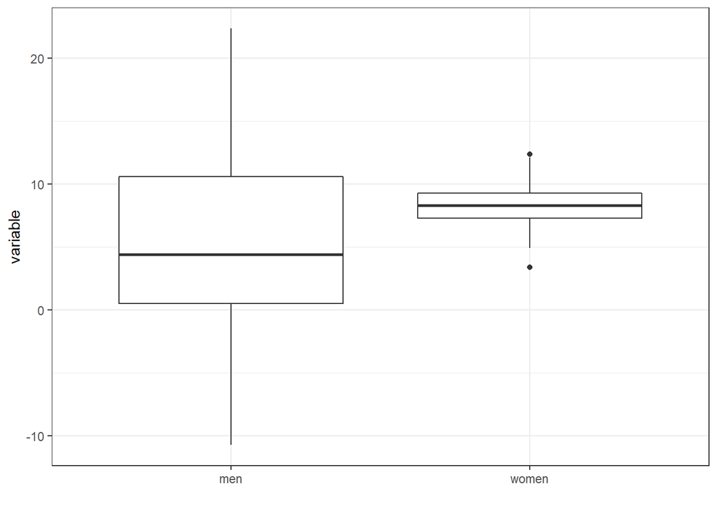

```r
ggplot(data = dataset_3,
       aes(x = group, y = variable)) +
  geom_boxplot() +
  labs(x = "")
```

##### Variance homogeneity

The null hypothesis, that the ratio of the variances is *equal* to 1, can now be rejected.

```r
var.test(variable ~ group, data = dataset_3)
```

```
##
##  F test to compare two variances
##
## data:  variable by group
## F = 16.73, num df = 49, denom df = 49, p-value < 2.2e-16
## alternative hypothesis: true ratio of variances is not equal to 1
## 95 percent confidence interval:
##   9.493828 29.481263
## sample estimates:
## ratio of variances
##           16.72991
```

##### Welch t-test (two-tailed)

To perform a Welch t-test, the function `t.test()` is modified by setting the argument `var.equal = FALSE`.

```r
t.test(variable ~ group, data = dataset_3,
       alternative = "two.sided",
       mu = 0, var.equal = FALSE)
```

```
##
##  Welch Two Sample t-test
##
## data:  variable by group
## t = -2.7983, df = 54.837, p-value = 0.007075
## alternative hypothesis: true difference in means is not equal to 0
## 95 percent confidence interval:
##  -5.1788028 -0.8563735
## sample estimates:
##   mean in group men mean in group women
##            5.275228            8.292817
```

#### 2.2.3 Non-parametric alternative

If the data for the two groups are not normally distributed, it is recommended to use the **Mann-Whitney U test** (or **Wilcoxon rank sum test**). The null hypothesis of this test is that two samples come from the same population (have the same median) or, alternatively, whether observations in one sample tend to be larger than observations in the other. It assumes, however, that the two distributions are similar in shape.

##### Data

The dataset from the previous section is slightly modified such that the `variable` of interest for the two groups now follows a log normal distribution, which I created with function `rlnorm()`.

```r
set.seed(123)
dataset_4 <- tibble(
  men = rlnorm(50, meanlog = 1, sdlog = 0.6),
  women = rlnorm(50, meanlog = 1.2, sdlog = 0.6)
  ) %>%
  pivot_longer(cols = c(men, women),names_to = "group", values_to = "variable")

dataset_4
```

```
## # A tibble: 100 x 2
##    group variable
##    <chr>    <dbl>
##  1 men       1.94
##  2 women     3.87
##  3 men       2.37
##  4 women     3.26
##  5 men       6.93
##  6 women     3.24
##  7 men       2.84
##  8 women     7.55
##  9 men       2.94
## 10 women     2.90
## # ... with 90 more rows
```

##### Density plot

I use a density plot to assess the skewness of the distribution of `variable` in `dataset_4` by comparing it to its distribution in `dataset_2` from the previous section. It is similar in shape but cleary deviates from the normal distribution.

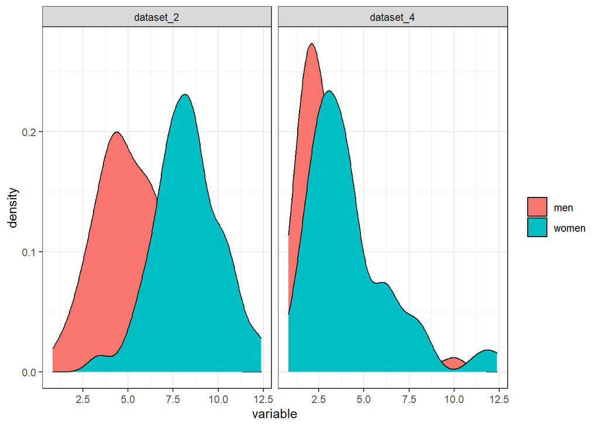

```r
bind_rows(
  list(dataset_2=dataset_2, dataset_4=dataset_4),
  .id = "source"
  ) %>%
  ggplot(data = .,
       aes(x = variable, fill = group)) +
  geom_density(position = "dodge", color = "black") +
  facet_wrap(. ~ source) +
  labs(fill = "")
```

##### Normality

The null hypothesis that the data follow a normal distribution is now strongly rejected for each group!

```r
with(dataset_4, shapiro.test(variable[group == "men"]))
```

```
##
##  Shapiro-Wilk normality test
##
## data:  variable[group == "men"]
## W = 0.86863, p-value = 5.146e-05
```

```r
with(dataset_4, shapiro.test(variable[group == "women"]))
```

```
##
##  Shapiro-Wilk normality test
##
## data:  variable[group == "women"]
## W = 0.87171, p-value = 6.328e-05
```

##### Wilcoxon rank sum test

Below the Wilcoxon rank sum test is computed with function `wilcox.test()` and setting argument `paired = FALSE`. The null hypothesis is that the distribution of `variable` between `men` and `women` differ by a location shift of `mu` and the alternative is that they differ by some other location shift.

```r
wilcox.test(variable ~ group, data = dataset_4,
            alternative = "two.sided",
            mu = 0, paired = FALSE)
```

```
##
##  Wilcoxon rank sum test with continuity correction
##
## data:  variable by group
## W = 898, p-value = 0.01539
## alternative hypothesis: true location shift is not equal to 0
```

We can conclude that the median value of `variable` for men is significantly different from the median of `variable` for women at the 5% level.

### 2.3 Two-samples paired t-test

The paired samples t-test is similiar in its assumptions to the unpaired t-test except that it requires that the two groups of samples are **related**. For example this is the case when *the same individual is observed at different time points*.

#### 2.3.1 Parametric version

##### Data

The next dataset is generated such that 50 individuals which are identified by an `id` were observed before and after a treatment. The observations are drawn from a normal distribution but the parameters differ before and after the treatment.

```r
set.seed(123)
dataset_5 <- tibble(
  id = c(1:50),
  before_treatment = rnorm(50, mean = 3, sd = 1),
  after_treatment = rnorm(50, mean = 5, sd = 1)
  ) %>%
  pivot_longer(cols = c(before_treatment, after_treatment),
               names_to = "group", values_to = "variable")

dataset_5
```

```
## # A tibble: 100 x 3
##       id group            variable
##    <int> <chr>               <dbl>
##  1     1 before_treatment     2.44
##  2     1 after_treatment      5.25
##  3     2 before_treatment     2.77
##  4     2 after_treatment      4.97
##  5     3 before_treatment     4.56
##  6     3 after_treatment      4.96
##  7     4 before_treatment     3.07
##  8     4 after_treatment      6.37
##  9     5 before_treatment     3.13
## 10     5 after_treatment      4.77
## # ... with 90 more rows
```

##### Boxplot

The distribution of `variable` is shown with a boxplot before and after the treatment. Additionally, I connected each pair of `id`. The observations are not independent!

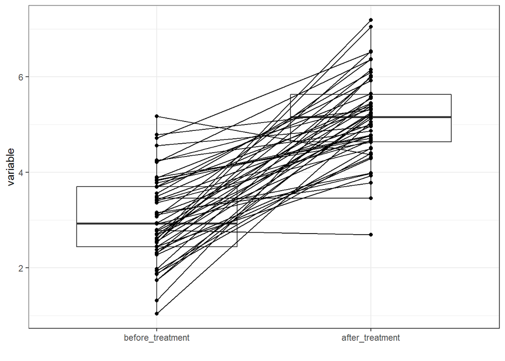

```r
ggplot(data = dataset_5,
       aes(x = reorder(group, variable), y = variable)) +
  geom_boxplot() +
  geom_point() +
  geom_line(aes(group = factor(id))) +
  labs(x = "")
```

##### Normality

The Shapiro-Wilk-Test is computed as always but now the `difference` between each pair of observations has to be used. The null hypothesis, that the differences before and after the treatment follow a normal distribution, cannot be rejected.

```r
dataset_5 %>%
  pivot_wider(id_cols = id, names_from = "group", values_from="variable") %>%
  mutate(difference = after_treatment - before_treatment) %>%
  pull(difference) %>%
  shapiro.test()
```

```
##
##  Shapiro-Wilk normality test
##
## data:  .
## W = 0.98276, p-value = 0.6727
```

Let’s have a look at the distribution of the `difference`.

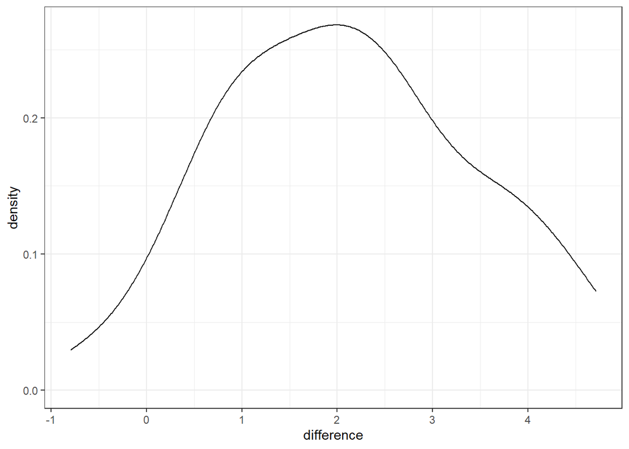

```r
dataset_5 %>%
  pivot_wider(id_cols = id, names_from = "group", values_from="variable") %>%
  mutate(difference = after_treatment - before_treatment) %>%
  ggplot(aes(x=difference)) + geom_density()
```

##### t-test (two-tailed)

The t-test for dependent groups can be computed by setting the argument `paired =` to `TRUE` in function `t.test()`. Since I did not check the assumption of variance homogeneity the default `var.equal = FALSE` is in place. The null hypothesis is that the difference of the mean value of `variable` before and after the treatment is equal to zero.

```r
t.test(variable ~ group, data = dataset_5,
       alternative = "two.sided",
       mu = 0,
       paired = TRUE)
```

```
##
##  Paired t-test
##
## data:  variable by group
## t = 11.331, df = 49, p-value = 2.711e-15
## alternative hypothesis: true difference in means is not equal to 0
## 95 percent confidence interval:
##  1.737424 2.486586
## sample estimates:
## mean of the differences
##                2.112005
```

The null hypothesis is rejected in favor of the alternative that there is a significant difference in the mean of `variable` before and after the treatment.

#### 2.3.2 Non-parametric alternative

Should the data not follow a normal distribution, it is recommended to use a **Wilcoxon signed rank test** instead of the t-test.

##### Data

Now, a dataset is generated where observations are related but drawn from a log normal distribution.

```r
set.seed(123)
dataset_6 <- tibble(
  id = c(1:50),
  before_treatment = rlnorm(50, meanlog = 2, sdlog = 0.7),
  after_treatment = rlnorm(50, meanlog = 1, sdlog = 0.6)
  ) %>%
  pivot_longer(cols = c(before_treatment, after_treatment),
               names_to = "group", values_to = "variable")

dataset_6
```

```
## # A tibble: 100 x 3
##       id group            variable
##    <int> <chr>               <dbl>
##  1     1 before_treatment     4.99
##  2     1 after_treatment      3.16
##  3     2 before_treatment     6.29
##  4     2 after_treatment      2.67
##  5     3 before_treatment    22.0
##  6     3 after_treatment      2.65
##  7     4 before_treatment     7.76
##  8     4 after_treatment      6.18
##  9     5 before_treatment     8.09
## 10     5 after_treatment      2.37
## # ... with 90 more rows
```

##### Density plot

I use a density plot to assess the skewness of the distribution before and after treatment by comparing it to the distribution in `dataset_5`.

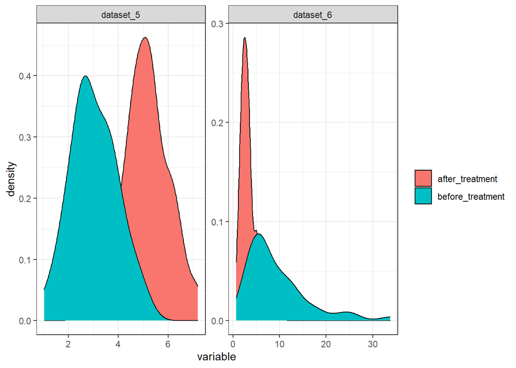

```r
bind_rows(
  list(dataset_5=dataset_5, dataset_6=dataset_6),
  .id = "source"
  ) %>%
  ggplot(data = .,
       aes(x = variable, fill = group)) +
  geom_density(position = "dodge", color = "black") +
  facet_wrap(. ~ source, scales = "free") +
  labs(fill = "")
```

##### Normality

There is no difference compared to the previous section, except that the null hypothesis, that the difference before and after the treatment follows a normal distribution, is now rejected.

```r
dataset_6 %>%
  pivot_wider(id_cols = id, names_from = "group", values_from="variable") %>%
  mutate(difference = after_treatment - before_treatment) %>%
  pull(difference) %>%
  shapiro.test()
```

```
##
##  Shapiro-Wilk normality test
##
## data:  .
## W = 0.90492, p-value = 0.0007013
```

The distribution of `difference` looks rather skewed now.

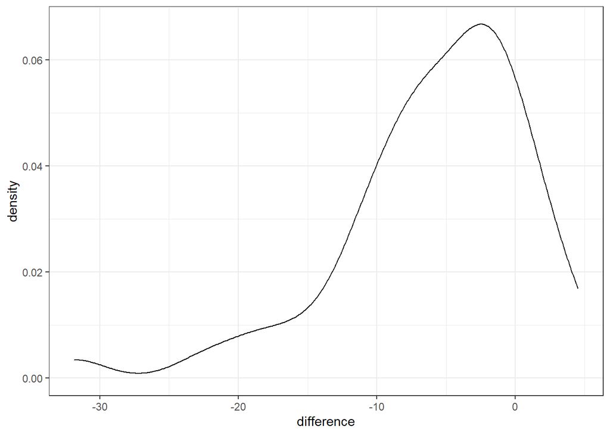

```r
dataset_6 %>%
  pivot_wider(id_cols = id, names_from = "group", values_from="variable") %>%
  mutate(difference = after_treatment - before_treatment) %>%
  ggplot(aes(x=difference)) + geom_density()
```

##### Wilcoxon signed rank test

In function `wilcox.test()` the argument `paired =` must be set to `TRUE` to perform this test. It tests whether the distribution of the two groups is symmetric about `mu`. In other words, the median of the differences before and after treatment are compared to a hypothetical median.

```r
wilcox.test(variable ~ group, data = dataset_6,
            alternative = "two.sided",
            mu = 0,
            paired = TRUE)
```

```
##
##  Wilcoxon signed rank test with continuity correction
##
## data:  variable by group
## V = 100, p-value = 2.174e-07
## alternative hypothesis: true location shift is not equal to 0
```

The null hypothesis that the median differences before and after the treatment are equal to zero can be rejected.

## 3. Analysis of Variance (ANOVA)

### 3.1 One-way ANOVA

The one-way analysis of variance (ANOVA), or one-factor ANOVA, is an extension of the independent two-samples t-test. It compares means in a situation where there are more than two groups. The data is split into several groups based on one single grouping variable (also called factor variable). ANOVA assumes that the observations are obtained independently and randomly from the population defined by the factor levels and the data of each factor level is normally distributed. Also the assumption of variance homogeneity, previously discussed by the t-test, applies here.

The ANOVA is performed with the following steps:

- Compute the variance between groups
- Compute the variance within groups (residual variance)
- Determine the degrees of freedom
- Calculate the F-statistic as the ratio of between variance and within variance

#### 3.1.1 Equal variance between groups

##### Data

I am generating 30 observations for three different groups which are drawn from a normal distribution with different means but identical standard deviations. The column `group` is declared as a factor variable with function `factor()`.

```r
set.seed(345)
dataset_7 <- tibble(
  group_A = rnorm(30, mean = 1, sd = 2),
  group_C = rnorm(30, mean = 4, sd = 2),
  group_B = rnorm(30, mean = 3, sd = 2)
  ) %>%
  pivot_longer(cols = starts_with("group"),
               names_to = "group",
               names_pattern = "._(.+)",
               values_to = "variable") %>%
  mutate(group = factor(group))

dataset_7
```

```
## # A tibble: 90 x 2
##    group variable
##    <fct>    <dbl>
##  1 A       -0.570
##  2 C        2.51
##  3 B        1.70
##  4 A        0.441
##  5 C        5.37
##  6 B        1.83
##  7 A        0.677
##  8 C        2.07
##  9 B        4.22
## 10 A        0.419
## # ... with 80 more rows
```

With function `levels()` the unique values of a factor variable can be displayed. When performing an ANOVA with an unbalanced design, that means unequal cell sizes, the order of the levels is important.

```r
levels(dataset_7$group)
```

```
## [1] "A" "B" "C"
```

```r
dataset_7$group <- ordered(dataset_7$group,
                           levels = c("A", "B", "C"))
```

##### Plot

Below I plot all observations per group using the function `geom_jitter()` which makes the distribution of `variable` more visible. I am adding the standard deviation from the mean with function `geom_errorbar()`.

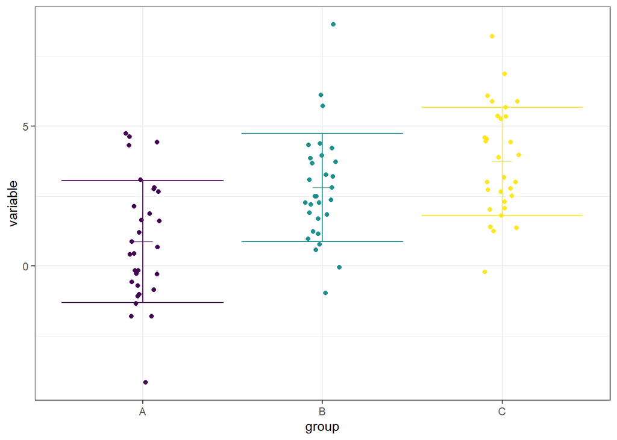

```r
dataset_7 %>%
group_by(group) %>%
  summarise(
    mean = mean(variable, na.rm = TRUE),
    sd = sd(variable, na.rm = TRUE)
  ) %>%
  left_join(dataset_7) %>%
  ggplot(data = .,
       aes(x = group, y = variable, col = group)) +
  geom_jitter(width = 0.1) +
  geom_errorbar(aes(ymin = mean - sd, ymax = mean + sd)) +
  geom_point(aes(y = mean), size = 5, shape = 3) +
  theme(legend.position = "none")
```

##### Computation

First we have to compute the means of `variable` for each `group` as well as the overall mean regardless of `group`. To save some coding effort I create subsets of `dataset_7` for each group.

```r
group_A <- dataset_7 %>% filter(group == "A")
group_B <- dataset_7 %>% filter(group == "B")
group_C <- dataset_7 %>% filter(group == "C")

A_mean <- mean(group_A$variable)
B_mean <- mean(group_B$variable)
C_mean <- mean(group_C$variable)
Overall_mean <- mean(dataset_7$variable, na.rm =T)
```

To obtain the **between variance** the squared differences between the mean of each group and the overall mean are computed.

The **within variance** is computed as the sum of the squared differences between each observation and its group mean.

The degrees of freedom for the between variance are calculated by substracting 1 from the number of distinct groups. The degress of freedom for the within variance are calculated by substracting the number of distrinct groups from the number of observations.

The F-statistic is the ratio of the between and within variance adjusted by the degress of freedom. The p-value can be calculcated with function `pf()`.

```r
knitr::kable(tibble(
  between_variance = 30*(A_mean-Overall_mean)^2 +
                     30*(B_mean-Overall_mean)^2 +
                     30*(C_mean-Overall_mean)^2,
  within_variance = sum((group_A$variable - mean(group_A$variable))^2) +
                   sum((group_B$variable - mean(group_B$variable))^2) +
                   sum((group_C$variable - mean(group_C$variable))^2),
  df_between = 3-1,
  df_within = 90-3,
  F_stat = (between_variance/df_between) / (within_variance/df_within),
  pval = pf(F_stat, 2, 87, lower.tail = FALSE)
  )
)
```

| between_variance | within_variance | df_between | df_within | F_stat | pval |
| --- | --- | --- | --- | --- | --- |
| 129.0416 | 355.1128 | 2 | 87 | 15.80711 | 1.4e-06 |

##### ANOVA

The one-way ANOVA can be calculated way more easily with function `aov()` and the results are displayed with function `summary()`. The null hypothesis is that there are no differences regarding `variable` between the levels of `group`.

```r
model_aov <- aov(variable ~ group, data = dataset_7)

summary(model_aov)
```

```
##             Df Sum Sq Mean Sq F value   Pr(>F)
## group        2  129.0   64.52   15.81 1.39e-06 ***
## Residuals   87  355.1    4.08
## ---
## Signif. codes:  0 '***' 0.001 '**' 0.01 '*' 0.05 '.' 0.1 ' ' 1
```

Using function `lm()` to compute the anova yields the same results with a little bit more precision but we have to use function `anova()` instead of `summary()` to get the desired output.

```r
model_lm <- lm(variable ~ group, data = dataset_7)
anova(model_lm)
```

```
## Analysis of Variance Table
##
## Response: variable
##           Df Sum Sq Mean Sq F value    Pr(>F)
## group      2 129.04  64.521  15.807 1.394e-06 ***
## Residuals 87 355.11   4.082
## ---
## Signif. codes:  0 '***' 0.001 '**' 0.01 '*' 0.05 '.' 0.1 ' ' 1
```

As the p-value is less than the significance level of 5 %, we can conclude that there are significant differences between the groups. However, we do not know which pairs of groups are different.

##### Tukey HSD

It is possible to perform multiple pairwise-comparisons to determine whether the mean differences between specific pairs of groups are statistically significant. This is can be done by computing **Tukey Honest Significant Differences** with function `TukeyHSD()`. It takes the fitted ANOVA as an argument.

```r
TukeyHSD(model_aov)
```

```
##   Tukey multiple comparisons of means
##     95% family-wise confidence level
##
## Fit: aov(formula = variable ~ group, data = dataset_7)
##
## $group
##          diff        lwr      upr     p adj
## B-A 1.9378958  0.6940356 3.181756 0.0010356
## C-A 2.8756463  1.6317862 4.119506 0.0000011
## C-B 0.9377505 -0.3061096 2.181611 0.1763757
```

We can conclude that there are significant differences between the means of group A and group B as well as group A and group C but not between group B and group C.

##### Variance homogeneity

An ANOVA assumes that the variance between each group’s observations is homogeneous. Either **Bartlett’s test** or **Levene’s test** can be used to test this assumption. The null hypothesis is that the variance across groups is homogeneous.

```r
car::leveneTest(variable  ~ group, data = dataset_7)
```

```
## Levene's Test for Homogeneity of Variance (center = median)
##       Df F value Pr(>F)
## group  2  0.5639 0.5711
##       87
```

```r
bartlett.test(variable ~ group, data = dataset_7)
```

```
##
##  Bartlett test of homogeneity of variances
##
## data:  variable by group
## Bartlett's K-squared = 0.52506, df = 2, p-value = 0.7691
```

Both tests show that there is no evidence to suggest that the variance across groups is significantly different.

Also a scatterplot might be used to check whether there is a relationship between residuals and the fitted values (which are the mean of each group in this setting). The straight blue line connects the mean of each group’s residuals. Pay special attention to outliers in this type of plot as they can strongly influence the above tests! Here, everything looks fine. Note that this plot requires an `lm` object and can hence only be created *after* running the ANOVA.

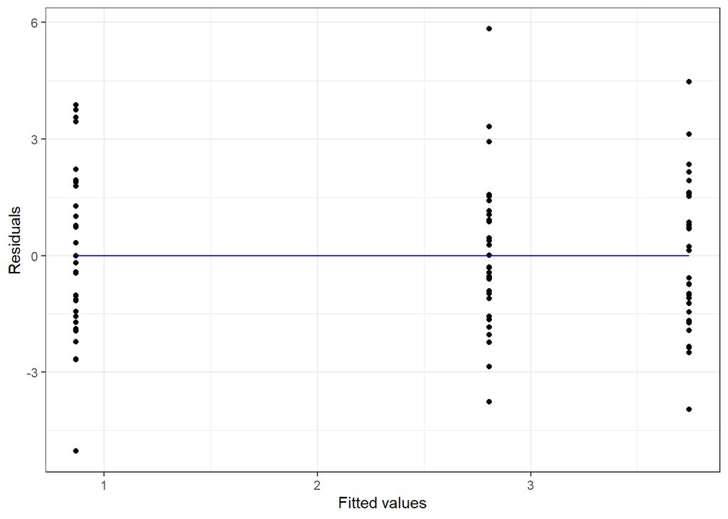

```r
broom::augment(model_lm) %>%
  group_by(group) %>%
  summarise(mean_resid = mean(.resid)) %>%
  left_join(broom::augment(model_lm)) %>%
  ggplot(data = .,
         aes(x = .fitted, y = .resid)) +
  geom_point() +
  geom_line(aes(y = mean_resid), color = "blue") +
  labs(x = "Fitted values", y = "Residuals")
```

##### Normality

The **Shapiro-Wilk test**, which was already used with the Student’s t-test, is used to check the distribution of the residuals. The null hypothesis is that the residuals follow a normal distribution. The function `residuals()` is used to extract the residuals from either the object created by `aov()` or `lm()`.

```r
model_aov_residuals <- residuals(object = model_aov)

shapiro.test(x = model_aov_residuals)
```

```
##
##  Shapiro-Wilk normality test
##
## data:  model_aov_residuals
## W = 0.98789, p-value = 0.5769
```

The null hypothesis that the residuals are normally distributed cannot be rejected.

For assessing the normality assumption I am also creating a **Q-Q (quantile-quantile) plot** of the residuals with functions `stat_qq()` and `stat_qq_line()`. Approximately, the residuals should follow a straight line.

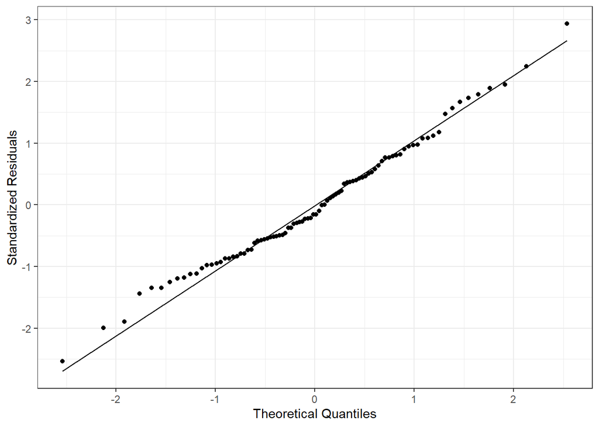

```r
ggplot(broom::augment(model_lm),
       aes(sample = .std.resid)) +
  stat_qq() +
  stat_qq_line() +
  labs(x = "Theoretical Quantiles",
       y = "Standardized Residuals")
```

#### 3.1.2 Unequal variance between groups

##### Data

Again, I am creating 30 observations for three different groups which are drawn from a normal distribution but now with different means and standard deviations.

```r
set.seed(345)
dataset_8 <- tibble(
  group_A = rnorm(30, mean = 1, sd = 2),
  group_C = rnorm(30, mean = 4, sd = 5),
  group_B = rnorm(30, mean = 3, sd = 8)
  ) %>%
  pivot_longer(cols = starts_with("group"),
               names_to = "group",
               names_pattern = "._(.+)",
               values_to = "variable") %>%
  mutate(group = ordered(group,
                         levels = c("A", "B", "C")))

dataset_8
```

```
## # A tibble: 90 x 2
##    group variable
##    <ord>    <dbl>
##  1 A       -0.570
##  2 C        0.285
##  3 B       -2.21
##  4 A        0.441
##  5 C        7.42
##  6 B       -1.67
##  7 A        0.677
##  8 C       -0.821
##  9 B        7.87
## 10 A        0.419
## # ... with 80 more rows
```

##### Plot

Let us take a look at the modified dataset. By comparing the distance between the error bars of each group, it is easy to see that there is a different spread within each group compared to the previous section.

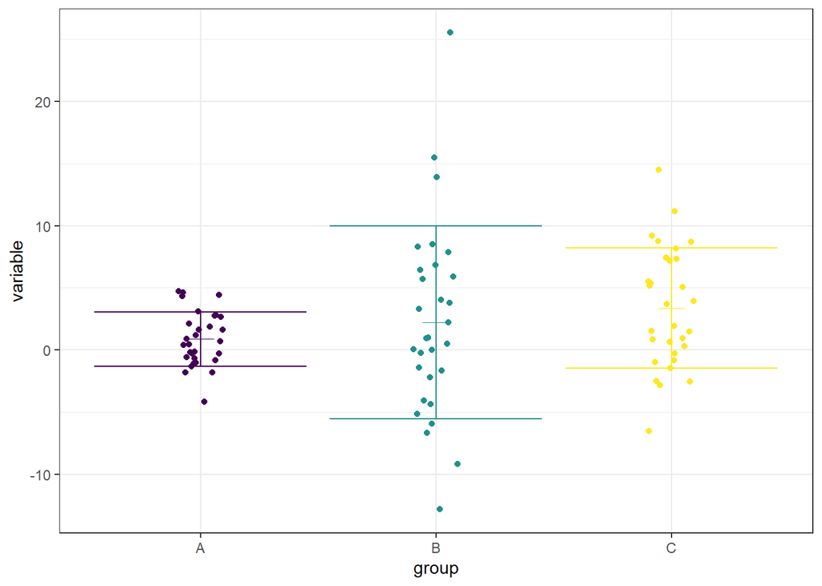

```r
dataset_8 %>%
group_by(group) %>%
  summarise(
    mean = mean(variable, na.rm = TRUE),
    sd = sd(variable, na.rm = TRUE)
  ) %>%
  left_join(dataset_8) %>%
  ggplot(data = .,
       aes(x = group, y = variable, col = group)) +
  geom_jitter(width = 0.1) +
  geom_errorbar(aes(ymin = mean - sd, ymax = mean + sd)) +
  geom_point(aes(y = mean), size = 5, shape = 3) +
  theme(legend.position = "none")
```

##### Variance homogeneity

Now I am running again both tests to test whether the variance between the three groups is homogeneous.

```r
car::leveneTest(variable  ~ group, data = dataset_8)
```

```
## Levene's Test for Homogeneity of Variance (center = median)
##       Df F value    Pr(>F)
## group  2  9.6438 0.0001649 ***
##       87
## ---
## Signif. codes:  0 '***' 0.001 '**' 0.01 '*' 0.05 '.' 0.1 ' ' 1
```

```r
bartlett.test(variable  ~ group, data = dataset_8)
```

```
##
##  Bartlett test of homogeneity of variances
##
## data:  variable by group
## Bartlett's K-squared = 38.319, df = 2, p-value = 4.776e-09
```

In both tests the null hypothesis that the variance between groups is homogeneous is rejected. Now a test, which does not assume equal variance is required

##### Welch one-way test

The **Welch one-way test** is designed to do this and can be performed with function `oneway.test()`. It tests whether two or more samples, which follow a normal distribution, have the same means.

```r
oneway.test(variable ~ group, data = dataset_8,
            var.equal = FALSE)
```

```
##
##  One-way analysis of means (not assuming equal variances)
##
## data:  variable and group
## F = 3.4606, num df = 2.000, denom df = 47.205, p-value = 0.03959
```

The null hypothesis that the group’s means are equal can be rejected at the 5 % level in favor of the alternative that they are different.

##### Pairwise t-tests

With function `pairwise.t.test()` comparisons between group levels can be calculated. The argument `pool.sd =` has to be set to `FALSE`.

```r
pairwise.t.test(dataset_8$variable, dataset_8$group,
                pool.sd = FALSE)
```

```
##
##  Pairwise comparisons using t tests with non-pooled SD
##
## data:  dataset_8$variable and dataset_8$group
##
##   A     B
## B 0.727 -
## C 0.042 0.727
##
## P value adjustment method: holm
```

There are significant differences between group `A` and group `C` but not between group `A` and group `B` as well as group `B` and group `C`.

#### 3.1.3. Non-parametric alternative

A non-parametric alternative to the one-way ANOVA is the **Kruskal-Wallis rank sum test**, which can be used when the normality assumption is violated.

##### Data

Below I create another 30 observations for three different groups which are now drawn from a log normal distribution.

```r
set.seed(345)
dataset_9 <-
  tibble(
    group_A = rlnorm(30, meanlog = 1.0, sdlog = 0.3),
    group_C = rlnorm(30, meanlog = 1.5, sdlog = 0.3),
    group_B = rlnorm(30, meanlog = 1.8, sdlog = 0.3)
    ) %>%
  pivot_longer(cols = starts_with("group"),
               names_to = "group",
               names_pattern = "._(.+)",
               values_to = "variable") %>%
  mutate(group =
           ordered(group, levels = c("A", "B", "C"))
         )

dataset_9
```

```
## # A tibble: 90 x 2
##    group variable
##    <ord>    <dbl>
##  1 A         2.15
##  2 C         3.59
##  3 B         4.98
##  4 A         2.50
##  5 C         5.50
##  6 B         5.08
##  7 A         2.59
##  8 C         3.36
##  9 B         7.26
## 10 A         2.49
## # ... with 80 more rows
```

##### Density plot

I use a density plot to assess the skewness of the distribution of `variable` among the three groups in `dataset_9` by comparing it to its distribution in `dataset_7` from the previous section. The distribution of `variable` in dataset_9 is *skewed to the right*.

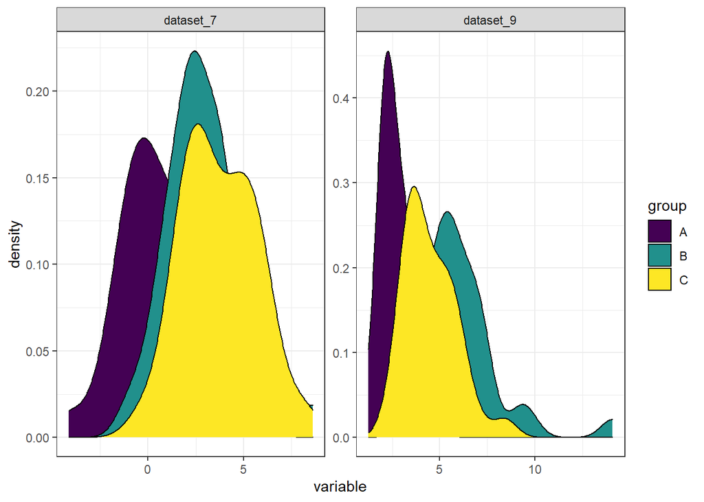

```r
bind_rows(
  list(dataset_7=dataset_7, dataset_9=dataset_9),
  .id = "source"
  ) %>%
  ggplot(data = .,
       aes(x = variable, fill = group)) +
  geom_density(position = "dodge", color = "black") +
  facet_wrap(. ~ source, scales = "free")
```

##### Normality

Using the function `shapiro.test()`, the null hypothesis that the residuals are normally distributed is now rejected.

```r
model_aov_residuals <- residuals(object = lm(variable ~ group, data = dataset_9))

shapiro.test(x = model_aov_residuals)
```

```
##
##  Shapiro-Wilk normality test
##
## data:  model_aov_residuals
## W = 0.87061, p-value = 2.441e-07
```

The Q-Q plot of the residuals also shows the deviation from the normal distribution at the tails.

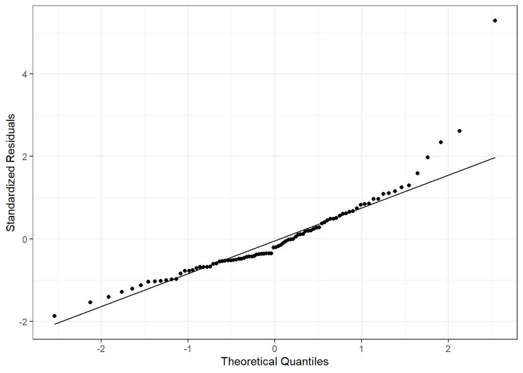

```r
ggplot(broom::augment(lm(variable ~ group, data = dataset_9)),
       aes(sample = .std.resid)) +
  stat_qq() +
  stat_qq_line() +
  labs(x = "Theoretical Quantiles",
       y = "Standardized Residuals")
```

##### Kruskal-Wallis Test

The function `kruskal.test()` performs a test of the null hypothesis that the location parameters of the distribution of `variable` are the same in each `group`. The alternative is that they differ in at least one.

```r
kruskal.test(variable ~ group, data = dataset_9)
```

```
##
##  Kruskal-Wallis rank sum test
##
## data:  variable by group
## Kruskal-Wallis chi-squared = 49.644, df = 2, p-value = 1.66e-11
```

The null hypothesis is rejected in favor of the alternative that the distribution of `variable` differs among the three groups.

With function `pairwise.wilcox.test()` pairwise comparisons between group levels may be calculated.

```r
pairwise.wilcox.test(dataset_9$variable, dataset_9$group)
```

```
##
##  Pairwise comparisons using Wilcoxon rank sum exact test
##
## data:  dataset_9$variable and dataset_9$group
##
##   A       B
## B 9.4e-13 -
## C 3.8e-07 0.00021
##
## P value adjustment method: holm
```

There are significant differences between all three groups.

### 3.2 Two-way ANOVA

The two-way analysis of variance is an extension of the one-way ANOVA and examines the influence of **two different categorical independent variables** on one continuous dependent variable. It not only aims at assessing the main effect of each independent variable but also if there is any interaction between them. The two-way ANOVA again assumes that the observations within each group are normally distributed and have equal variances.

The follwing hypotheses might be tested:

- There is no difference in the means of categories of variable A.
- There is no difference in the means of categories of variable B.
- There is no interaction between the variables A and B.

#### 3.2.1 Balanced Design

The first section discusses an ANOVA when the study’s design is balanced. This means that for each combination of the two factor variables there are the same number of observations (cell counts).

##### Data

Below, I am generating a dataset with 60 observations. They are split within `group` (A, B, C) and `country` (DE, EN), hence there are 10 observations per combination of the two factor variables. The `variable` of interest is drawn from a normal distribution. The mean differs within and between `group` and `country` while the standard deviation only differs between `country`.

```r
set.seed(345)
dataset_10 <- tibble(
  DE_group_A = rnorm(10, mean = 1, sd = 1),
  DE_group_B = rnorm(10, mean = 2, sd = 1),
  DE_group_C = rnorm(10, mean = 3, sd = 1),
  EN_group_A = rnorm(10, mean = 2, sd = 1.4),
  EN_group_B = rnorm(10, mean = 4, sd = 1.4),
  EN_group_C = rnorm(10, mean = 6, sd = 1.4)
  ) %>%
  pivot_longer(cols = everything(),
               names_to = c("country", "group"),
               names_pattern = "(.*)_group_(.*)",
               values_to = "variable") %>%
  mutate(group = factor(group),
         country = factor(country))
```

The cell counts can be checked with a two-way table.

```r
dataset_10 %>%
  select(country, group) %>%
  table()
```

```
##        group
## country  A  B  C
##      DE 10 10 10
##      EN 10 10 10
```

Here, the design is balanced.

##### Boxplot

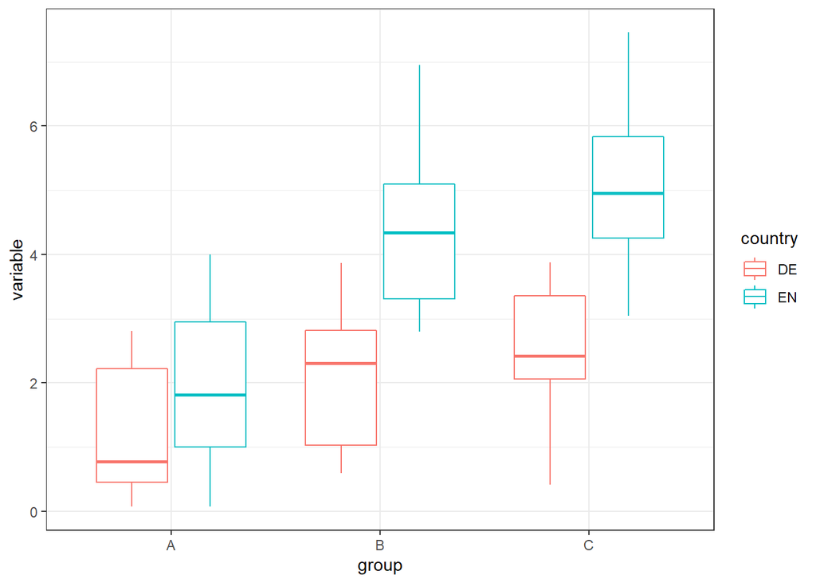

```r
ggplot(data = dataset_10,
       aes(x = group, y = variable, color = country)) +
  geom_boxplot()
```

##### ANOVA

The two-way ANOVA is carried out in the same fashion as in the previous section. The second factor variable is added via a `+` in the formula of function `aov()`.

```r
model_aov2 <- aov(variable ~ country + group, data = dataset_10)

summary(model_aov2)
```

```
##             Df Sum Sq Mean Sq F value   Pr(>F)
## country      1  53.38   53.38   34.62 2.34e-07 ***
## group        2  53.94   26.97   17.49 1.25e-06 ***
## Residuals   56  86.34    1.54
## ---
## Signif. codes:  0 '***' 0.001 '**' 0.01 '*' 0.05 '.' 0.1 ' ' 1
```

Both `country` and `group` are statistically significant and influence the mean of `variable` length.

The above fitted model is called an *additive model*. It makes the assumption that the two factor variables `country` and `group` are independent. If there are reasons to believe that these two variables might interact, that is they depend on each other, the formula of function `aov()` has to be adjusted by adding `country:group`.

```r
model_aov_interact <- aov(variable ~ country + group + country:group, data = dataset_10)

summary(model_aov_interact)
```

```
##               Df Sum Sq Mean Sq F value   Pr(>F)
## country        1  53.38   53.38  37.528 1.07e-07 ***
## group          2  53.94   26.97  18.958 5.79e-07 ***
## country:group  2   9.53    4.76   3.349   0.0425 *
## Residuals     54  76.82    1.42
## ---
## Signif. codes:  0 '***' 0.001 '**' 0.01 '*' 0.05 '.' 0.1 ' ' 1
```

The interaction is still statistically significant at the 5 % level. Hence, the relationship between `group` and `variable` does depend on `country`. If the interaction is not significant the additive model is preferred.

##### Means

With function `model.tables()` summary tables for model fits can be printed. It displays the overall mean, the means per level of each factor variable as well as the means of the combinations of both factor’s levels.

```r
model.tables(model_aov_interact, type = "means", se = TRUE)
```

```
## Tables of means
## Grand mean
##
## 2.877139
##
##  country
## country
##    DE    EN
## 1.934 3.820
##
##  group
## group
##     A     B     C
## 1.585 3.212 3.834
##
##  country:group
##        group
## country A     B     C
##      DE 1.203 2.034 2.564
##      EN 1.968 4.390 5.104
##
## Standard errors for differences of means
##         country  group country:group
##          0.3080 0.3772        0.5334
## replic.      30     20            10
```

##### Tukey HSD

Similarly to the one-way ANOVA, a significant p-value indicates that the group means are different, but we do not know exactly which pairs. Again, we can compute Tukey Honest Significant Differences to perform multiple pairwise-comparisons between the means of groups.

The argument `which =` of function `TukeyHSD()` can take a list of character values as input and hence we can test both factor variables (`country` and `group`) at once.

```r
TukeyHSD(model_aov_interact, which = c("country", "group"))
```

```
##   Tukey multiple comparisons of means
##     95% family-wise confidence level
##
## Fit: aov(formula = variable ~ country + group + country:group, data = dataset_10)
##
## $country
##           diff      lwr      upr p adj
## EN-DE 1.886507 1.269101 2.503912 1e-07
##
## $group
##          diff        lwr      upr     p adj
## B-A 1.6266655  0.7177109 2.535620 0.0002010
## C-A 2.2488666  1.3399120 3.157821 0.0000006
## C-B 0.6222011 -0.2867535 1.531156 0.2339918
```

Irrespective of `group`, we find that there are statistically significant differences between countries DE and EN. Also we find that there are statistically significant differences between group A and B as well as group A and C but not between group B and C irrespective of `country`.

Alternatively, we can also use a pairwise t-test to consider all possible combinations of the categorical variables. I’m using the function `str_c()` to combine the vectors `group` and `country`.

```r
pairwise.t.test(dataset_10$variable, str_c(dataset_10$group, dataset_10$country, sep = "-"))
```

```
##
##  Pairwise comparisons using t tests with pooled SD
##
## data:  dataset_10$variable and str_c(dataset_10$group, dataset_10$country, sep = "-")
##
##      A-DE    A-EN    B-DE    B-EN    C-DE
## A-EN 0.78787 -       -       -       -
## B-DE 0.74968 0.90070 -       -       -
## B-EN 2.6e-06 0.00032 0.00044 -       -
## C-DE 0.09505 0.80470 0.80470 0.00953 -
## C-EN 1.9e-08 3.4e-06 5.0e-06 0.78787 0.00016
##
## P value adjustment method: holm
```

##### Assumptions

Variance homogeneity: The null hypothesis that the variance between samples is homogeneous cannot be rejected.

```r
car::leveneTest(variable ~ country*group, data = dataset_10)
```

```
## Levene's Test for Homogeneity of Variance (center = median)
##       Df F value Pr(>F)
## group  5   0.388 0.8549
##       54
```

Normality: The null hypothesis that the residuals are normally distributed cannot be rejected.

```r
model_aov_interact_residuals <- residuals(object = lm(variable ~ country*group, data = dataset_10))

shapiro.test(x = model_aov_interact_residuals)
```

```
##
##  Shapiro-Wilk normality test
##
## data:  model_aov_interact_residuals
## W = 0.97825, p-value = 0.3592
```

#### 3.2.2 Unbalanced Designs

An unbalanced design has unequal numbers of subjects in each group. In general there are three different ways to run an ANOVA and as long as a study’s design is balanced these methods lead to the same results. However, when dealing with an unbalanced design is is recommended to calculate **Type-II or Type-III** sums of squares.

##### Data

In order to create an unbalanced design I use the same dataset from the previous section (balanced design) and introduce missing values (`NA`) in each group.

```r
set.seed(345)
dataset_11 <- tibble(
  DE_group_A = c(rnorm(8, mean = 1, sd = 1), NA,NA),
  DE_group_B = c(rnorm(7, mean = 2, sd = 1), NA, NA, NA),
  DE_group_C = c(rnorm(9, mean = 3, sd = 1), NA),
  EN_group_A = c(rnorm(9, mean = 2, sd = 1.4), NA),
  EN_group_B = c(rnorm(10, mean = 4, sd = 1.4)),
  EN_group_C = c(rnorm(8, mean = 6, sd = 1.4), NA, NA)
  ) %>%
  pivot_longer(cols = everything(),
               names_to = c("country", "group"),
               names_pattern = "(.*)_group_(.*)",
               values_to = "variable") %>%
  mutate(group = factor(group),
         country = factor(country)) %>%
  filter(!is.na(variable))
```

Below we can see the unequal cell counts. They vary between 7 and 10.

```r
dataset_11 %>%
  select(country, group) %>%
  table()
```

```
##        group
## country  A  B  C
##      DE  8  7  9
##      EN  9 10  8
```

##### Boxplot

With a boxplot is not possible to see whether a dataset inherits a balanced design or not, so always use frequency tables to check for it.

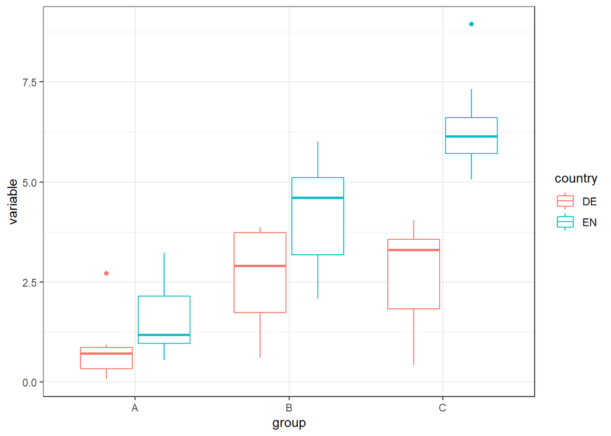

```r
ggplot(data = dataset_11,
       aes(x = group, y = variable, color = country)) +
  geom_boxplot()
```

##### Type-I

The first type is also known as *sequential sum of squares* because the *sequence* of the specified independent variables matters. In R’s `anova()` and `aov()` functions this type is implemented and the ANOVA should be run two times, once with each independent variable taking the lead.

```r
summary(aov(variable ~ country*group, data = dataset_11))
```

```
##               Df Sum Sq Mean Sq F value   Pr(>F)
## country        1  47.00   47.00  34.394 4.96e-07 ***
## group          2  97.40   48.70  35.642 5.29e-10 ***
## country:group  2  19.91    9.95   7.284  0.00182 **
## Residuals     45  61.49    1.37
## ---
## Signif. codes:  0 '***' 0.001 '**' 0.01 '*' 0.05 '.' 0.1 ' ' 1
```

```r
summary(aov(variable ~ group*country, data = dataset_11))
```

```
##               Df Sum Sq Mean Sq F value   Pr(>F)
## group          2  93.54   46.77  34.226 9.20e-10 ***
## country        1  50.87   50.87  37.225 2.21e-07 ***
## group:country  2  19.91    9.95   7.284  0.00182 **
## Residuals     45  61.49    1.37
## ---
## Signif. codes:  0 '***' 0.001 '**' 0.01 '*' 0.05 '.' 0.1 ' ' 1
```

The difference in the main effects of `country` and `group` is only due to which variable comes first. Also note that the interaction effect is not affected by the ordering of the independent variables.

##### Type-II

For the second type the sequence of the arguments in the model does not matter! We can use the function `Anova()` from package `car` and specify `type = "II"` to obtain the desired results.

```r
model_aov2 <- aov(variable ~ country*group, data = dataset_11)

car::Anova(model_aov2, type = "II")
```

```
## Anova Table (Type II tests)
##
## Response: variable
##               Sum Sq Df F value    Pr(>F)
## country       50.865  1 37.2248 2.209e-07 ***
## group         97.404  2 35.6417 5.286e-10 ***
## country:group 19.907  2  7.2844  0.001817 **
## Residuals     61.489 45
## ---
## Signif. codes:  0 '***' 0.001 '**' 0.01 '*' 0.05 '.' 0.1 ' ' 1
```

##### Type-III

The third type is also known as *partial sums of squares*. Again we use the function `Anova()` from package `car` and specify `type = "III"`.

```r
model_aov3 <- aov(variable ~ country*group, data = dataset_11)

car::Anova(model_aov3, type = "III")
```

```
## Anova Table (Type III tests)
##
## Response: variable
##               Sum Sq Df F value   Pr(>F)
## (Intercept)    5.388  1  3.9433 0.053171 .
## country        2.251  1  1.6476 0.205850
## group         17.765  2  6.5004 0.003312 **
## country:group 19.907  2  7.2844 0.001817 **
## Residuals     61.489 45
## ---
## Signif. codes:  0 '***' 0.001 '**' 0.01 '*' 0.05 '.' 0.1 ' ' 1
```

The effect of `group` is still statistically significant but the influence of `country` is not! The p-value of the interaction term is identical to the previous settings.

## 4. Multivariate Analysis of Variance (MANOVA)

A multivariate analysis of variance (MANOVA) is simply an ANOVA with more than one dependent variable. Hence, while an ANOVA tests for the difference in means between two or more groups, the MANOVA tests for the difference in two or more vectors of means.

### Data

I create a dataset where two variables of interest (`height` and `weight`) are drawn from a normal distribution for three different `groups`. In total there are 60 observations of the two variables of interest - 20 for each group.

```r
set.seed(345)
dataset_12 <- tibble(
  height_group_A = rnorm(20, mean = 3.0, sd = 1.0),
  height_group_B = rnorm(20, mean = 4.5, sd = 1.0),
  height_group_C = rnorm(20, mean = 3.5, sd = 1.0),
  weight_group_A = rnorm(20, mean = 5.0, sd = 1.0),
  weight_group_B = rnorm(20, mean = 6.5, sd = 1.0),
  weight_group_C = rnorm(20, mean = 5.5, sd = 1.0)
  ) %>%
  pivot_longer(cols = everything(),
               names_to = c(".value", "group"),
               names_pattern = "(.+)_group_(.)"
               ) %>%
  mutate(group = factor(group))

dataset_12
```

```
## # A tibble: 60 x 3
##    group height weight
##    <fct>  <dbl>  <dbl>
##  1 A       2.22   4.35
##  2 B       4.94   7.86
##  3 C       4.13   4.14
##  4 A       2.72   4.42
##  5 B       5.33   5.58
##  6 C       4.34   5.01
##  7 A       2.84   5.61
##  8 B       1.92   5.48
##  9 C       2.65   6.38
## 10 A       2.71   3.79
## # ... with 50 more rows
```

### Scatterplot

Since there is more than one continuous variable, I am using a scatterplot to show the distribution of `height` and `weight` between `group` A, B and C.

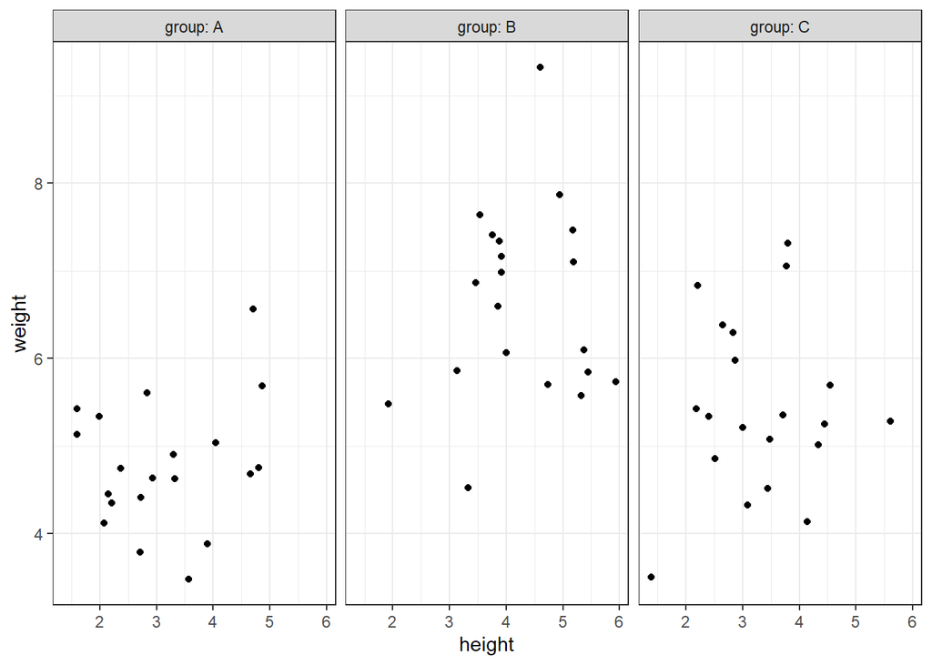

```r
ggplot(data = dataset_12,
       aes(x = height, y = weight)) +
  geom_point() +
  facet_wrap(. ~ group,  labeller = purrr::partial(label_both, sep = ": "))
```

### MANOVA

With function `cbind()` the `height` and `weight` variable are combined and then used as dependent variables in function `manova()`.

```r
model_manova <- manova(cbind(height, weight) ~ group, data = dataset_12)
summary(model_manova)
```

```
##           Df  Pillai approx F num Df den Df    Pr(>F)
## group      2 0.46724   8.6879      4    114 3.708e-06 ***
## Residuals 57
## ---
## Signif. codes:  0 '***' 0.001 '**' 0.01 '*' 0.05 '.' 0.1 ' ' 1
```

Below is another output for both responses individually. There are also significant differences between the groups for each dependent variable.

```r
summary.aov(model_manova)
```

```
##  Response height :
##             Df Sum Sq Mean Sq F value  Pr(>F)
## group        2 15.145  7.5726  7.1769 0.00166 **
## Residuals   57 60.142  1.0551
## ---
## Signif. codes:  0 '***' 0.001 '**' 0.01 '*' 0.05 '.' 0.1 ' ' 1
##
##  Response weight :
##             Df Sum Sq Mean Sq F value    Pr(>F)
## group        2 35.123 17.5613  19.638 3.252e-07 ***
## Residuals   57 50.972  0.8942
## ---
## Signif. codes:  0 '***' 0.001 '**' 0.01 '*' 0.05 '.' 0.1 ' ' 1
```

### Multivariate normality

Similar to the ANOVA we can use the Shapiro-Wilk test to check the distribution of the residuals. The null hypothesis is that the residuals follow a normal distribution. The function residuals() is used to extract the residuals from the object created by function `manova()`. However, we can only check for univariate normality with this test.

```r
model_manova_residuals <- residuals(object = model_manova)

shapiro.test(x = model_manova_residuals)
```

```
##
##  Shapiro-Wilk normality test
##
## data:  model_manova_residuals
## W = 0.99062, p-value = 0.5905
```

The null hypothesis that the residuals are univariate normally distributed cannot be rejected.

In addition there is **Mardia’skewness and kurtosis test* for multivariate normality. It is implemented in function `mardia` in package `mvnormalTest`.

```r
mvnormalTest::mardia(cbind(dataset_12$height, dataset_12$weight))
```

```
## $mv.test
##           Test Statistic p-value Result
## 1     Skewness    4.2945  0.3676    YES
## 2     Kurtosis   -1.2815     0.2    YES
## 3 MV Normality      <NA>    <NA>    YES
##
## $uv.shapiro
##    W      p-value UV.Normality
## V1 0.9812 0.4818  Yes
## V2 0.9695 0.1374  Yes
```

The null hypothesis that the dependent variables are multivariate normally distributed cannot be rejected.

### Variance homogeneity

When perfoming a MANOVA the data should have equal variance-covariance matrices for each combination formed by each group in the independent variable. This is a multivariate version of the homogeneity of variances described in the ANOVA section. We can use **Box’s M test** implemented in function `boxM()` in package `heplots`.

```r
heplots::boxM(cbind(height, weight) ~ group, data = dataset_12)
```

```
##
##  Box's M-test for Homogeneity of Covariance Matrices
##
## data:  Y
## Chi-Sq (approx.) = 3.3773, df = 6, p-value = 0.7602
```

The null hypothesis that the covariance matrices are homogeneous cannot be rejected.

### Multicollinearity

Also we need to check for multicollinearity among our two dependent variables `height` and `weight`. Correlation is measured between -1 and 1 where zero indicates no correlation and -1/1 perfect negative/positive correlation.

```r
cor(dataset_12$height, dataset_12$weight)
```

```
## [1] 0.3606827
```

## 5. Bootstrapping

As a non-parametric estimation method, the bootstrap quantifies the uncertainty of an estimator involved with the standard deviation. This can for example be very helpful if the sample size is relatively small or when the underlying distribution cannot be approximated parametrically.

### Data

I create a dataset with 30 observations of two variables of interest (`height` and `weight`) which are sampled from a range of given values.

```r
set.seed(345)
dataset_13 <- tibble(
  height = sample(170:190, 30, replace = TRUE),
  weight = sample(70:90, 30, replace = TRUE)
  )

dataset_13
```

```
## # A tibble: 30 x 2
##    height weight
##     <int>  <int>
##  1    188     80
##  2    190     88
##  3    187     70
##  4    189     74
##  5    177     78
##  6    170     81
##  7    178     90
##  8    171     75
##  9    188     86
## 10    174     70
## # ... with 20 more rows
```

### Parametric mean

For variable `height` I calculate the mean and its standard error.

```r
mean(dataset_13$height)
```

```
## [1] 179.4333
```

```r
sd(dataset_13$height)/sqrt(length(dataset_13$height))
```

```
## [1] 1.20505
```

### Bootstrapped mean

Before we are able to perform the bootstrap, a specific function is required which must allow for subsetting the dataset. Below I am generating a new function `mean_indexed()` which uses the argument `indices` to subset the supplied `data`.

```r
mean_indexed <- function(data, indices){
  mean(data[indices])
  }
```

Now with function `boot()` from R package `boot` the bootstrap can be calculated. In order to get replicable results a seed must be set. Then I am using the above generated function `mean_indexed()` with argument `statistic =` and set `R = 1000` to create 1000 replications (samples).

```r
set.seed(345)
bootMean <- boot(dataset_13$height, statistic = mean_indexed, R = 1000)

summary(bootMean)
```

```
##      R original  bootBias bootSE bootMed
## 1 1000   179.43 -0.045633 1.2248  179.38
```

The `original` mean is `179.43`. The `bootBias` represents the difference between the original and bootstrapped value of the mean. The bootstrapped standard error (`bootSE`) is 1.2248. The values shown above can also be calculated by using the 1000 replicated mean values contained in `t` inside object `bootMean`.

```r
mean(bootMean$t)
```

```
## [1] 179.3877
```

```r
sd(bootMean$t)
```

```
## [1] 1.224809
```

### Comparison

```r
options(pillar.sigfig = 5)
tibble(
  variable = c("height", "height"),
  type = c("parametric", "bootstrap"),
  mean = c(mean(dataset_13$height), mean(bootMean$t)),
  se = c(sd(dataset_13$height)/sqrt(length(dataset_13$height)), sd(bootMean$t))
  )
```

```
## # A tibble: 2 x 4
##   variable type         mean     se
##   <chr>    <chr>       <dbl>  <dbl>
## 1 height   parametric 179.43 1.2051
## 2 height   bootstrap  179.39 1.2248
```

### Correlation

Below is another example on how to use the bootstrap. I want to estimate the correlation between `height` and `weight` with the bootstrap.

```r
cor_indexed <- function(data, indices){
  cor(data[indices,]$height, data[indices,]$weight)
  }

set.seed(345)
bootCor <- boot(dataset_13, statistic = cor_indexed, R = 1000)

options(pillar.sigfig = 5)
tibble(
  correlation_paramteric = cor(dataset_13$height, dataset_13$weight),
  correlation_bootstrap = mean(bootCor$t)
  )
```

```
## # A tibble: 1 x 2
##   correlation_paramteric correlation_bootstrap
##                    <dbl>                 <dbl>
## 1               0.053863              0.049370
```